# Define Problem Statement and perform Exploratory Data Analysis

- Delhivery, India’s largest and fastest-growing fully integrated logistics provider, generates massive volumes of trip-level operational data through its data engineering pipelines. This raw data contains complex, multi-row trip records, segment-level routing information, distance and time metrics, and diverse categorical attributes related to transportation, routes, and logistics operations.
- To support Delhivery’s mission of building an intelligent, high-quality, and efficient logistics operating system, the data must be converted into reliable, structured, and analysis-ready features. The challenge lies in cleaning, merging, interpreting, and engineering features from this fragmented dataset so that it can be used effectively for forecasting, optimization, and decision-making.
- This project focuses on:
  - Cleaning and sanitizing raw trip data, handling missing values, inconsistencies, and outliers.
  - Merging multi-row trip entries into unified trip-level records using appropriate aggregations.
  - Engineering meaningful features from timestamps, location names, and routing information.
  - Evaluating relationships between actual vs. OSRM travel times and distances.
  - Standardizing, normalizing, and encoding columns for model readiness.
  - Deriving insights on network efficiency, route performance, and operational bottlenecks.
- By transforming raw logistics data into high-quality analytical features, this work helps the Data Science team build robust forecasting models, optimize transportation routes, and drive better strategic and operational decisions—ultimately contributing to Delhivery’s competitive advantage in speed, efficiency, and profitability.

```python
import pandas as pd
import numpy as np
import matplotlib.pyplot as plt
import seaborn as sns
```

## Importing Data

```python
df = pd.read_csv("/content/drive/MyDrive/01. Data Set for Colab Notebooks/delhivery_data.csv")
```

```python
df.head(3)
```

|  | data | trip_creation_time | route_schedule_uuid | route_type | trip_uuid | source_center | source_name | destination_center | destination_name | od_start_time | ... | cutoff_timestamp | actual_distance_to_destination | actual_time | osrm_time | osrm_distance | factor | segment_actual_time | segment_osrm_time | segment_osrm_distance | segment_factor |
| --- | --- | --- | --- | --- | --- | --- | --- | --- | --- | --- | --- | --- | --- | --- | --- | --- | --- | --- | --- | --- | --- |
| 0 | training | 2018-09-20 02:35:36.476840 | thanos::sroute:eb7bfc78-b351-4c0e-a951-fa3d5c3... | Carting | trip-153741093647649320 | IND388121AAA | Anand_VUNagar_DC (Gujarat) | IND388620AAB | Khambhat_MotvdDPP_D (Gujarat) | 2018-09-20 03:21:32.418600 | ... | 2018-09-20 04:27:55 | 10.435660 | 14.0 | 11.0 | 11.9653 | 1.272727 | 14.0 | 11.0 | 11.9653 | 1.272727 |
| 1 | training | 2018-09-20 02:35:36.476840 | thanos::sroute:eb7bfc78-b351-4c0e-a951-fa3d5c3... | Carting | trip-153741093647649320 | IND388121AAA | Anand_VUNagar_DC (Gujarat) | IND388620AAB | Khambhat_MotvdDPP_D (Gujarat) | 2018-09-20 03:21:32.418600 | ... | 2018-09-20 04:17:55 | 18.936842 | 24.0 | 20.0 | 21.7243 | 1.200000 | 10.0 | 9.0 | 9.7590 | 1.111111 |
| 2 | training | 2018-09-20 02:35:36.476840 | thanos::sroute:eb7bfc78-b351-4c0e-a951-fa3d5c3... | Carting | trip-153741093647649320 | IND388121AAA | Anand_VUNagar_DC (Gujarat) | IND388620AAB | Khambhat_MotvdDPP_D (Gujarat) | 2018-09-20 03:21:32.418600 | ... | 2018-09-20 04:01:19.505586 | 27.637279 | 40.0 | 28.0 | 32.5395 | 1.428571 | 16.0 | 7.0 | 10.8152 | 2.285714 |

3 rows × 24 columns

## Basic Data Exploration

```python
print(f"The dataset has {df.shape[0]} rows and {df.shape[1]} columns")
```

```
The dataset has 144867 rows and 24 columns
```

```python
df.info()
```

```
<class 'pandas.core.frame.DataFrame'>
RangeIndex: 144867 entries, 0 to 144866
Data columns (total 24 columns):
 #   Column                          Non-Null Count   Dtype
---  ------                          --------------   -----
 0   data                            144867 non-null  object
 1   trip_creation_time              144867 non-null  object
 2   route_schedule_uuid             144867 non-null  object
 3   route_type                      144867 non-null  object
 4   trip_uuid                       144867 non-null  object
 5   source_center                   144867 non-null  object
 6   source_name                     144574 non-null  object
 7   destination_center              144867 non-null  object
 8   destination_name                144606 non-null  object
 9   od_start_time                   144867 non-null  object
```

[output cut: 16 more lines]

- It describes the distribution of the numeric attributes non-graphically

```python
df.describe()
```

|  | start_scan_to_end_scan | cutoff_factor | actual_distance_to_destination | actual_time | osrm_time | osrm_distance | factor | segment_actual_time | segment_osrm_time | segment_osrm_distance | segment_factor |
| --- | --- | --- | --- | --- | --- | --- | --- | --- | --- | --- | --- |
| count | 144867.000000 | 144867.000000 | 144867.000000 | 144867.000000 | 144867.000000 | 144867.000000 | 144867.000000 | 144867.000000 | 144867.000000 | 144867.00000 | 144867.000000 |
| mean | 961.262986 | 232.926567 | 234.073372 | 416.927527 | 213.868272 | 284.771297 | 2.120107 | 36.196111 | 18.507548 | 22.82902 | 2.218368 |
| std | 1037.012769 | 344.755577 | 344.990009 | 598.103621 | 308.011085 | 421.119294 | 1.715421 | 53.571158 | 14.775960 | 17.86066 | 4.847530 |
| min | 20.000000 | 9.000000 | 9.000045 | 9.000000 | 6.000000 | 9.008200 | 0.144000 | -244.000000 | 0.000000 | 0.00000 | -23.444444 |
| 25% | 161.000000 | 22.000000 | 23.355874 | 51.000000 | 27.000000 | 29.914700 | 1.604264 | 20.000000 | 11.000000 | 12.07010 | 1.347826 |
| 50% | 449.000000 | 66.000000 | 66.126571 | 132.000000 | 64.000000 | 78.525800 | 1.857143 | 29.000000 | 17.000000 | 23.51300 | 1.684211 |
| 75% | 1634.000000 | 286.000000 | 286.708875 | 513.000000 | 257.000000 | 343.193250 | 2.213483 | 40.000000 | 22.000000 | 27.81325 | 2.250000 |
| max | 7898.000000 | 1927.000000 | 1927.447705 | 4532.000000 | 1686.000000 | 2326.199100 | 77.387097 | 3051.000000 | 1611.000000 | 2191.40370 | 574.250000 |

- It describes the distribution of the string attributes non-graphically

```python
df.describe(include="O")
```

|  | data | trip_creation_time | route_schedule_uuid | route_type | trip_uuid | source_center | source_name | destination_center | destination_name | od_start_time | od_end_time | cutoff_timestamp |
| --- | --- | --- | --- | --- | --- | --- | --- | --- | --- | --- | --- | --- |
| count | 144867 | 144867 | 144867 | 144867 | 144867 | 144867 | 144574 | 144867 | 144606 | 144867 | 144867 | 144867 |
| unique | 2 | 14817 | 1504 | 2 | 14817 | 1508 | 1498 | 1481 | 1468 | 26369 | 26369 | 93180 |
| top | training | 2018-09-22 04:55:04.835022 | thanos::sroute:4029a8a2-6c74-4b7e-a6d8-f9e069f... | FTL | trip-153759210483476123 | IND000000ACB | Gurgaon_Bilaspur_HB (Haryana) | IND000000ACB | Gurgaon_Bilaspur_HB (Haryana) | 2018-09-21 18:37:09.322207 | 2018-09-24 09:59:15.691618 | 2018-09-24 05:19:20 |
| freq | 104858 | 101 | 1812 | 99660 | 101 | 23347 | 23347 | 15192 | 15192 | 81 | 81 | 40 |

- Column wise - count of unique values

```python
df.nunique()
```

|  | 0 |
| --- | --- |
| data | 2 |
| trip_creation_time | 14817 |
| route_schedule_uuid | 1504 |
| route_type | 2 |
| trip_uuid | 14817 |
| source_center | 1508 |
| source_name | 1498 |
| destination_center | 1481 |
| destination_name | 1468 |
| od_start_time | 26369 |
| od_end_time | 26369 |
| start_scan_to_end_scan | 1915 |
| is_cutoff | 2 |
| cutoff_factor | 501 |
| cutoff_timestamp | 93180 |
| actual_distance_to_destination | 144515 |
| actual_time | 3182 |
| osrm_time | 1531 |
| osrm_distance | 138046 |
| factor | 45641 |
| segment_actual_time | 747 |
| segment_osrm_time | 214 |
| segment_osrm_distance | 113799 |
| segment_factor | 5675 |

**dtype:** int64

## Missing Value Detection

```python
df.isnull().sum()
```

|  | 0 |
| --- | --- |
| data | 0 |
| trip_creation_time | 0 |
| route_schedule_uuid | 0 |
| route_type | 0 |
| trip_uuid | 0 |
| source_center | 0 |
| source_name | 293 |
| destination_center | 0 |
| destination_name | 261 |
| od_start_time | 0 |
| od_end_time | 0 |
| start_scan_to_end_scan | 0 |
| is_cutoff | 0 |
| cutoff_factor | 0 |
| cutoff_timestamp | 0 |
| actual_distance_to_destination | 0 |
| actual_time | 0 |
| osrm_time | 0 |
| osrm_distance | 0 |
| factor | 0 |
| segment_actual_time | 0 |
| segment_osrm_time | 0 |
| segment_osrm_distance | 0 |
| segment_factor | 0 |

**dtype:** int64

- source_name has 293 null values
- destination_name has 261 null values
- But these missing values don't impact our analysis as we have source_center and destination_center

## Introducing Feature 1 : unique key - to handle multi layer under each trip_uuid

```python
df['unique_key'] = df['trip_uuid'] + df['source_center'] + df['destination_center']
```

```python
df.head(3)
```

|  | data | trip_creation_time | route_schedule_uuid | route_type | trip_uuid | source_center | source_name | destination_center | destination_name | od_start_time | ... | actual_distance_to_destination | actual_time | osrm_time | osrm_distance | factor | segment_actual_time | segment_osrm_time | segment_osrm_distance | segment_factor | unique_key |
| --- | --- | --- | --- | --- | --- | --- | --- | --- | --- | --- | --- | --- | --- | --- | --- | --- | --- | --- | --- | --- | --- |
| 0 | training | 2018-09-20 02:35:36.476840 | thanos::sroute:eb7bfc78-b351-4c0e-a951-fa3d5c3... | Carting | trip-153741093647649320 | IND388121AAA | Anand_VUNagar_DC (Gujarat) | IND388620AAB | Khambhat_MotvdDPP_D (Gujarat) | 2018-09-20 03:21:32.418600 | ... | 10.435660 | 14.0 | 11.0 | 11.9653 | 1.272727 | 14.0 | 11.0 | 11.9653 | 1.272727 | trip-153741093647649320IND388121AAAIND388620AAB |
| 1 | training | 2018-09-20 02:35:36.476840 | thanos::sroute:eb7bfc78-b351-4c0e-a951-fa3d5c3... | Carting | trip-153741093647649320 | IND388121AAA | Anand_VUNagar_DC (Gujarat) | IND388620AAB | Khambhat_MotvdDPP_D (Gujarat) | 2018-09-20 03:21:32.418600 | ... | 18.936842 | 24.0 | 20.0 | 21.7243 | 1.200000 | 10.0 | 9.0 | 9.7590 | 1.111111 | trip-153741093647649320IND388121AAAIND388620AAB |
| 2 | training | 2018-09-20 02:35:36.476840 | thanos::sroute:eb7bfc78-b351-4c0e-a951-fa3d5c3... | Carting | trip-153741093647649320 | IND388121AAA | Anand_VUNagar_DC (Gujarat) | IND388620AAB | Khambhat_MotvdDPP_D (Gujarat) | 2018-09-20 03:21:32.418600 | ... | 27.637279 | 40.0 | 28.0 | 32.5395 | 1.428571 | 16.0 | 7.0 | 10.8152 | 2.285714 | trip-153741093647649320IND388121AAAIND388620AAB |

3 rows × 25 columns

```python
cols = ['segment_actual_time','segment_osrm_distance','segment_osrm_time']
for c in cols:
  df[c + '_sum'] = df.groupby('unique_key')[c].cumsum()

df[[c + '_sum' for c in cols]]
```

|  | segment_actual_time_sum | segment_osrm_distance_sum | segment_osrm_time_sum |
| --- | --- | --- | --- |
| 0 | 14.0 | 11.9653 | 11.0 |
| 1 | 24.0 | 21.7243 | 20.0 |
| 2 | 40.0 | 32.5395 | 27.0 |
| 3 | 61.0 | 45.5619 | 39.0 |
| 4 | 67.0 | 49.4772 | 44.0 |
| ... | ... | ... | ... |
| 144862 | 92.0 | 65.3487 | 94.0 |
| 144863 | 118.0 | 82.7212 | 115.0 |
| 144864 | 138.0 | 103.4265 | 149.0 |
| 144865 | 155.0 | 122.3150 | 176.0 |
| 144866 | 423.0 | 131.1238 | 185.0 |

144867 rows × 3 columns

- Aggregating at Sub-Journey Level

```python
create_unique_dict = {

    'data' : 'first',
    'trip_creation_time': 'first',
    'route_schedule_uuid' : 'first',
    'route_type' : 'first',
    'trip_uuid' : 'first',
    'source_center' : 'first',
    'source_name' : 'first',

    'destination_center' : 'last',
    'destination_name' : 'last',

    'od_start_time' : 'first',
    'od_end_time' : 'first',
    'start_scan_to_end_scan' : 'first',


    'actual_distance_to_destination' : 'last',
    'actual_time' : 'last',

    'osrm_time' : 'last',
    'osrm_distance' : 'last',

    'segment_actual_time_sum' : 'last',
    'segment_osrm_distance_sum' : 'last',
    'segment_osrm_time_sum' : 'last',

    }
```

- Groupby mini-trips, sorting by time

```python
unique = df.groupby('unique_key').agg(create_unique_dict).reset_index()
unique = unique.sort_values(by=['unique_key','od_end_time'], ascending=True).reset_index()
```

```python
unique.head()
```

|  | index | unique_key | data | trip_creation_time | route_schedule_uuid | route_type | trip_uuid | source_center | source_name | destination_center | ... | od_start_time | od_end_time | start_scan_to_end_scan | actual_distance_to_destination | actual_time | osrm_time | osrm_distance | segment_actual_time_sum | segment_osrm_distance_sum | segment_osrm_time_sum |
| --- | --- | --- | --- | --- | --- | --- | --- | --- | --- | --- | --- | --- | --- | --- | --- | --- | --- | --- | --- | --- | --- |
| 0 | 0 | trip-153671041653548748IND209304AAAIND000000ACB | training | 2018-09-12 00:00:16.535741 | thanos::sroute:d7c989ba-a29b-4a0b-b2f4-288cdc6... | FTL | trip-153671041653548748 | IND209304AAA | Kanpur_Central_H_6 (Uttar Pradesh) | IND000000ACB | ... | 2018-09-12 16:39:46.858469 | 2018-09-13 13:40:23.123744 | 1260.0 | 383.759164 | 732.0 | 329.0 | 446.5496 | 728.0 | 670.6205 | 534.0 |
| 1 | 1 | trip-153671041653548748IND462022AAAIND209304AAA | training | 2018-09-12 00:00:16.535741 | thanos::sroute:d7c989ba-a29b-4a0b-b2f4-288cdc6... | FTL | trip-153671041653548748 | IND462022AAA | Bhopal_Trnsport_H (Madhya Pradesh) | IND209304AAA | ... | 2018-09-12 00:00:16.535741 | 2018-09-12 16:39:46.858469 | 999.0 | 440.973689 | 830.0 | 388.0 | 544.8027 | 820.0 | 649.8528 | 474.0 |
| 2 | 2 | trip-153671042288605164IND561203AABIND562101AAA | training | 2018-09-12 00:00:22.886430 | thanos::sroute:3a1b0ab2-bb0b-4c53-8c59-eb2a2c0... | Carting | trip-153671042288605164 | IND561203AAB | Doddablpur_ChikaDPP_D (Karnataka) | IND562101AAA | ... | 2018-09-12 02:03:09.655591 | 2018-09-12 03:01:59.598855 | 58.0 | 24.644021 | 47.0 | 26.0 | 28.1994 | 46.0 | 28.1995 | 26.0 |
| 3 | 3 | trip-153671042288605164IND572101AAAIND561203AAB | training | 2018-09-12 00:00:22.886430 | thanos::sroute:3a1b0ab2-bb0b-4c53-8c59-eb2a2c0... | Carting | trip-153671042288605164 | IND572101AAA | Tumkur_Veersagr_I (Karnataka) | IND561203AAB | ... | 2018-09-12 00:00:22.886430 | 2018-09-12 02:03:09.655591 | 122.0 | 48.542890 | 96.0 | 42.0 | 56.9116 | 95.0 | 55.9899 | 39.0 |
| 4 | 4 | trip-153671043369099517IND000000ACBIND160002AAC | training | 2018-09-12 00:00:33.691250 | thanos::sroute:de5e208e-7641-45e6-8100-4d9fb1e... | FTL | trip-153671043369099517 | IND000000ACB | Gurgaon_Bilaspur_HB (Haryana) | IND160002AAC | ... | 2018-09-14 03:40:17.106733 | 2018-09-14 17:34:55.442454 | 834.0 | 237.439610 | 611.0 | 212.0 | 281.2109 | 608.0 | 317.7408 | 231.0 |

5 rows × 21 columns

```python
unique.info()
```

```
<class 'pandas.core.frame.DataFrame'>
RangeIndex: 26368 entries, 0 to 26367
Data columns (total 21 columns):
 #   Column                          Non-Null Count  Dtype
---  ------                          --------------  -----
 0   index                           26368 non-null  int64
 1   unique_key                      26368 non-null  object
 2   data                            26368 non-null  object
 3   trip_creation_time              26368 non-null  object
 4   route_schedule_uuid             26368 non-null  object
 5   route_type                      26368 non-null  object
 6   trip_uuid                       26368 non-null  object
 7   source_center                   26368 non-null  object
 8   source_name                     26302 non-null  object
 9   destination_center              26368 non-null  object
 10  destination_name                26287 non-null  object
 11  od_start_time                   26368 non-null  object
 12  od_end_time                     26368 non-null  object
 13  start_scan_to_end_scan          26368 non-null  float64
 14  actual_distance_to_destination  26368 non-null  float64
 15  actual_time                     26368 non-null  float64
 16  osrm_time                       26368 non-null  float64
 17  osrm_distance                   26368 non-null  float64
 18  segment_actual_time_sum         26368 non-null  float64
 19  segment_osrm_distance_sum       26368 non-null  float64
 20  segment_osrm_time_sum           26368 non-null  float64
dtypes: float64(8), int64(1), object(12)
memory usage: 4.2+ MB
```

## Introducing Feature 2 : od_time_diff_mins - Time taken between od_start_time and od_end_time

```python
unique['od_start_time'] = pd.to_datetime(unique['od_start_time'])
unique['od_end_time'] = pd.to_datetime(unique['od_end_time'])

unique['od_time_diff_mins'] = (unique['od_end_time'] - unique['od_start_time']).dt.total_seconds() / (60)
unique['od_time_diff_mins']
```

|  | od_time_diff_mins |
| --- | --- |
| 0 | 1260.604421 |
| 1 | 999.505379 |
| 2 | 58.832388 |
| 3 | 122.779486 |
| 4 | 834.638929 |
| ... | ... |
| 26363 | 62.115193 |
| 26364 | 91.087797 |
| 26365 | 44.174403 |
| 26366 | 287.474007 |
| 26367 | 66.933565 |

26368 rows × 1 columns

**dtype:** float64

## Aggregating at trip level

```python
create_trip_dict = {

    'data' : 'first',
    'trip_creation_time': 'first',
    'route_schedule_uuid' : 'first',
    'route_type' : 'first',
    'trip_uuid' : 'first',

    'source_center' : 'first',
    'source_name' : 'first',

    'destination_center' : 'last',
    'destination_name' : 'last',

    'start_scan_to_end_scan' : 'sum',
    'od_time_diff_mins' : 'sum',

    'actual_distance_to_destination' : 'sum',
    'actual_time' : 'sum',
    'osrm_time' : 'sum',
    'osrm_distance' : 'sum',

    'segment_actual_time_sum' : 'sum',
    'segment_osrm_distance_sum' : 'sum',
    'segment_osrm_time_sum' : 'sum',

    }
```

```python
trip = unique.groupby('trip_uuid').agg(create_trip_dict).reset_index(drop = True)
```

```python
trip.head()
```

|  | data | trip_creation_time | route_schedule_uuid | route_type | trip_uuid | source_center | source_name | destination_center | destination_name | start_scan_to_end_scan | od_time_diff_mins | actual_distance_to_destination | actual_time | osrm_time | osrm_distance | segment_actual_time_sum | segment_osrm_distance_sum | segment_osrm_time_sum |
| --- | --- | --- | --- | --- | --- | --- | --- | --- | --- | --- | --- | --- | --- | --- | --- | --- | --- | --- |
| 0 | training | 2018-09-12 00:00:16.535741 | thanos::sroute:d7c989ba-a29b-4a0b-b2f4-288cdc6... | FTL | trip-153671041653548748 | IND209304AAA | Kanpur_Central_H_6 (Uttar Pradesh) | IND209304AAA | Kanpur_Central_H_6 (Uttar Pradesh) | 2259.0 | 2260.109800 | 824.732854 | 1562.0 | 717.0 | 991.3523 | 1548.0 | 1320.4733 | 1008.0 |
| 1 | training | 2018-09-12 00:00:22.886430 | thanos::sroute:3a1b0ab2-bb0b-4c53-8c59-eb2a2c0... | Carting | trip-153671042288605164 | IND561203AAB | Doddablpur_ChikaDPP_D (Karnataka) | IND561203AAB | Doddablpur_ChikaDPP_D (Karnataka) | 180.0 | 181.611874 | 73.186911 | 143.0 | 68.0 | 85.1110 | 141.0 | 84.1894 | 65.0 |
| 2 | training | 2018-09-12 00:00:33.691250 | thanos::sroute:de5e208e-7641-45e6-8100-4d9fb1e... | FTL | trip-153671043369099517 | IND000000ACB | Gurgaon_Bilaspur_HB (Haryana) | IND000000ACB | Gurgaon_Bilaspur_HB (Haryana) | 3933.0 | 3934.362520 | 1927.404273 | 3347.0 | 1740.0 | 2354.0665 | 3308.0 | 2545.2678 | 1941.0 |
| 3 | training | 2018-09-12 00:01:00.113710 | thanos::sroute:f0176492-a679-4597-8332-bbd1c7f... | Carting | trip-153671046011330457 | IND400072AAB | Mumbai Hub (Maharashtra) | IND401104AAA | Mumbai_MiraRd_IP (Maharashtra) | 100.0 | 100.494935 | 17.175274 | 59.0 | 15.0 | 19.6800 | 59.0 | 19.8766 | 16.0 |
| 4 | training | 2018-09-12 00:02:09.740725 | thanos::sroute:d9f07b12-65e0-4f3b-bec8-df06134... | FTL | trip-153671052974046625 | IND583101AAA | Bellary_Dc (Karnataka) | IND583119AAA | Sandur_WrdN1DPP_D (Karnataka) | 717.0 | 718.349042 | 127.448500 | 341.0 | 117.0 | 146.7918 | 340.0 | 146.7919 | 115.0 |

```python
trip[trip['trip_uuid'] == 'trip-153741093647649320']
```

|  | data | trip_creation_time | route_schedule_uuid | route_type | trip_uuid | source_center | source_name | destination_center | destination_name | start_scan_to_end_scan | od_time_diff_mins | actual_distance_to_destination | actual_time | osrm_time | osrm_distance | segment_actual_time_sum | segment_osrm_distance_sum | segment_osrm_time_sum |
| --- | --- | --- | --- | --- | --- | --- | --- | --- | --- | --- | --- | --- | --- | --- | --- | --- | --- | --- |
| 5919 | training | 2018-09-20 02:35:36.476840 | thanos::sroute:eb7bfc78-b351-4c0e-a951-fa3d5c3... | Carting | trip-153741093647649320 | IND388121AAA | Anand_VUNagar_DC (Gujarat) | IND388320AAA | Anand_Vaghasi_IP (Gujarat) | 195.0 | 195.386819 | 82.981842 | 170.0 | 89.0 | 107.4515 | 167.0 | 102.7106 | 88.0 |

```python
trip[['actual_time', 'segment_actual_time_sum']]
```

|  | actual_time | segment_actual_time_sum |
| --- | --- | --- |
| 0 | 1562.0 | 1548.0 |
| 1 | 143.0 | 141.0 |
| 2 | 3347.0 | 3308.0 |
| 3 | 59.0 | 59.0 |
| 4 | 341.0 | 340.0 |
| ... | ... | ... |
| 14812 | 83.0 | 82.0 |
| 14813 | 21.0 | 21.0 |
| 14814 | 282.0 | 281.0 |
| 14815 | 264.0 | 258.0 |
| 14816 | 275.0 | 274.0 |

14817 rows × 2 columns

```python
trip[['actual_distance_to_destination','osrm_distance']]
```

|  | actual_distance_to_destination | osrm_distance |
| --- | --- | --- |
| 0 | 824.732854 | 991.3523 |
| 1 | 73.186911 | 85.1110 |
| 2 | 1927.404273 | 2354.0665 |
| 3 | 17.175274 | 19.6800 |
| 4 | 127.448500 | 146.7918 |
| ... | ... | ... |
| 14812 | 57.762332 | 73.4630 |
| 14813 | 15.513784 | 16.0882 |
| 14814 | 38.684839 | 58.9037 |
| 14815 | 134.723836 | 171.1103 |
| 14816 | 66.081533 | 80.5787 |

14817 rows × 2 columns

# Detecting Missing Value in trip

```python
missing_value = pd.DataFrame({'Missing Value': trip.isnull().sum(),'Percentage':(trip.isnull().sum()/len(trip))*100})
missing_value.sort_values(by='Percentage',ascending=False)
```

|  | Missing Value | Percentage |
| --- | --- | --- |
| source_name | 10 | 0.067490 |
| destination_name | 8 | 0.053992 |
| trip_creation_time | 0 | 0.000000 |
| data | 0 | 0.000000 |
| route_schedule_uuid | 0 | 0.000000 |
| route_type | 0 | 0.000000 |
| source_center | 0 | 0.000000 |
| trip_uuid | 0 | 0.000000 |
| destination_center | 0 | 0.000000 |
| start_scan_to_end_scan | 0 | 0.000000 |
| od_time_diff_mins | 0 | 0.000000 |
| actual_distance_to_destination | 0 | 0.000000 |
| actual_time | 0 | 0.000000 |
| osrm_time | 0 | 0.000000 |
| osrm_distance | 0 | 0.000000 |
| segment_actual_time_sum | 0 | 0.000000 |
| segment_osrm_distance_sum | 0 | 0.000000 |
| segment_osrm_time_sum | 0 | 0.000000 |

```python
trip.shape
```

```
(14817, 18)
```

## Removing Missing value from trip data

```python
trip = trip.dropna(subset=['source_name','destination_name'])
```

```python
missing_value = pd.DataFrame({'Missing Vallue': trip.isnull().sum(),'Percentage':(trip.isnull().sum()/len(trip))*100})
missing_value.sort_values(by='Percentage',ascending=False)
```

|  | Missing Vallue | Percentage |
| --- | --- | --- |
| data | 0 | 0.0 |
| trip_creation_time | 0 | 0.0 |
| route_schedule_uuid | 0 | 0.0 |
| route_type | 0 | 0.0 |
| trip_uuid | 0 | 0.0 |
| source_center | 0 | 0.0 |
| source_name | 0 | 0.0 |
| destination_center | 0 | 0.0 |
| destination_name | 0 | 0.0 |
| start_scan_to_end_scan | 0 | 0.0 |
| od_time_diff_mins | 0 | 0.0 |
| actual_distance_to_destination | 0 | 0.0 |
| actual_time | 0 | 0.0 |
| osrm_time | 0 | 0.0 |
| osrm_distance | 0 | 0.0 |
| segment_actual_time_sum | 0 | 0.0 |
| segment_osrm_distance_sum | 0 | 0.0 |
| segment_osrm_time_sum | 0 | 0.0 |

```python
trip.shape
```

```
(14800, 18)
```

## Lowering the case of source_name and destination_name

```python
trip['destination_name'] = trip['destination_name'].str.lower()
trip['source_name'] = trip['source_name'].str.lower()
```

## Defining Function to strip out State Name

```python
def place2state(x):
    state = x.split('(')[1] #splitting state based on"("
    return state[:-1] #removing ')' from end
```

## Defining Function to strip out City

```python
def place2city(x):
    # removing state
    city = x.split(' (')[0]
    # picking the first city name
    city = city.split('_')[0]

    # Now dealing with edge cases
    # ['PNQ Pashan DPC', 'Bhopal MP Nagar', 'HBR Layout PC',
    # 'PNQ Rahatani DPC', 'Pune Balaji Nagar', 'Mumbai Antop Hill']

    if city == 'pnq vadgaon sheri dpc':
      return 'vadgaonsheri'
    elif city in ['pnq pashan dpc','pnq rahatani dpc', 'pune balaji nagar']:
      return 'pune'
    elif city == 'hbr layout pc' :
      return 'bengaluru'
    elif city == 'bhopal mp nagar' :
      return 'bhopal'
    elif city == 'mumbai antop hill' :
      return 'mumbai'
    else:
      return city
```

## Defining Function to strip out Place

```python
def place2city_place(x):

    # We will remove state
    x = x.split(' (')[0]

    len1 = len(x.split('_'))

    if len1 >= 3:
        return x.split('_')[1]

    # Small cities have same city and place name
    if len1 == 2:
        return x.split('_')[0]

    return x.split(' ')[0]
```

## Defining Function to strip out Place Code

```python
def place2code(x):
    # Removing State
    x = x.split(' (')[0]

    if len(x.split('_')) >= 3 :
        return x.split('_')[-1]

    return 'none'
```

## Introducting 8 new features

```python
trip['source_state'] = trip['source_name'].apply(lambda x: place2state(x))
trip['source_city']  = trip['source_name'].apply(lambda x: place2city(x))
trip['source_place'] = trip['source_name'].apply(lambda x: place2city_place(x))
trip['source_code']  = trip['source_name'].apply(lambda x: place2code(x))

trip['destination_state'] = trip['destination_name'].apply(lambda x: place2state(x))
trip['destination_city']  = trip['destination_name'].apply(lambda x: place2city(x))
trip['destination_place'] = trip['destination_name'].apply(lambda x: place2city_place(x))
trip['destination_code']  = trip['destination_name'].apply(lambda x: place2code(x))
```

```python
trip[['source_state', 'source_city', 'source_place', 'source_code','destination_state', 'destination_city', 'destination_place', 'destination_code']]
```

|  | source_state | source_city | source_place | source_code | destination_state | destination_city | destination_place | destination_code |
| --- | --- | --- | --- | --- | --- | --- | --- | --- |
| 0 | uttar pradesh | kanpur | central | 6 | uttar pradesh | kanpur | central | 6 |
| 1 | karnataka | doddablpur | chikadpp | d | karnataka | doddablpur | chikadpp | d |
| 2 | haryana | gurgaon | bilaspur | hb | haryana | gurgaon | bilaspur | hb |
| 3 | maharashtra | mumbai hub | mumbai | none | maharashtra | mumbai | mirard | ip |
| 4 | karnataka | bellary | bellary | none | karnataka | sandur | wrdn1dpp | d |
| ... | ... | ... | ... | ... | ... | ... | ... | ... |
| 14812 | punjab | chandigarh | mehmdpur | h | punjab | chandigarh | mehmdpur | h |
| 14813 | haryana | fbd | balabhgarh | dpc | haryana | faridabad | blbgarh | dc |
| 14814 | uttar pradesh | kanpur | govndngr | dc | uttar pradesh | kanpur | govndngr | dc |
| 14815 | tamil nadu | tirunelveli | vdkkusrt | i | tamil nadu | tirchchndr | shnmgprm | d |
| 14816 | karnataka | sandur | wrdn1dpp | d | karnataka | sandur | wrdn1dpp | d |

14800 rows × 8 columns

- This will help us to make insights on
  - Busiest route
  - popular route

## Splitting the trip_creation_time to fetch insights

## Introducing 6 more features

```python
trip['trip_creation_time'] =  pd.to_datetime(trip['trip_creation_time']) # Converting string to datetime

trip['trip_year'] = trip['trip_creation_time'].dt.year
trip['trip_month'] = trip['trip_creation_time'].dt.month
trip['trip_hour'] = trip['trip_creation_time'].dt.hour
trip['trip_day'] = trip['trip_creation_time'].dt.day
trip['trip_week'] = trip['trip_creation_time'].dt.isocalendar().week
trip['trip_dayofweek'] = trip['trip_creation_time'].dt.dayofweek
```

- This will help us to get insights on :
  - Busiest Month
  - Busiest Week
  - Busiest Day

```python
trip.head()
```

|  | data | trip_creation_time | route_schedule_uuid | route_type | trip_uuid | source_center | source_name | destination_center | destination_name | start_scan_to_end_scan | ... | destination_state | destination_city | destination_place | destination_code | trip_year | trip_month | trip_hour | trip_day | trip_week | trip_dayofweek |
| --- | --- | --- | --- | --- | --- | --- | --- | --- | --- | --- | --- | --- | --- | --- | --- | --- | --- | --- | --- | --- | --- |
| 0 | training | 2018-09-12 00:00:16.535741 | thanos::sroute:d7c989ba-a29b-4a0b-b2f4-288cdc6... | FTL | trip-153671041653548748 | IND209304AAA | kanpur_central_h_6 (uttar pradesh) | IND209304AAA | kanpur_central_h_6 (uttar pradesh) | 2259.0 | ... | uttar pradesh | kanpur | central | 6 | 2018 | 9 | 0 | 12 | 37 | 2 |
| 1 | training | 2018-09-12 00:00:22.886430 | thanos::sroute:3a1b0ab2-bb0b-4c53-8c59-eb2a2c0... | Carting | trip-153671042288605164 | IND561203AAB | doddablpur_chikadpp_d (karnataka) | IND561203AAB | doddablpur_chikadpp_d (karnataka) | 180.0 | ... | karnataka | doddablpur | chikadpp | d | 2018 | 9 | 0 | 12 | 37 | 2 |
| 2 | training | 2018-09-12 00:00:33.691250 | thanos::sroute:de5e208e-7641-45e6-8100-4d9fb1e... | FTL | trip-153671043369099517 | IND000000ACB | gurgaon_bilaspur_hb (haryana) | IND000000ACB | gurgaon_bilaspur_hb (haryana) | 3933.0 | ... | haryana | gurgaon | bilaspur | hb | 2018 | 9 | 0 | 12 | 37 | 2 |
| 3 | training | 2018-09-12 00:01:00.113710 | thanos::sroute:f0176492-a679-4597-8332-bbd1c7f... | Carting | trip-153671046011330457 | IND400072AAB | mumbai hub (maharashtra) | IND401104AAA | mumbai_mirard_ip (maharashtra) | 100.0 | ... | maharashtra | mumbai | mirard | ip | 2018 | 9 | 0 | 12 | 37 | 2 |
| 4 | training | 2018-09-12 00:02:09.740725 | thanos::sroute:d9f07b12-65e0-4f3b-bec8-df06134... | FTL | trip-153671052974046625 | IND583101AAA | bellary_dc (karnataka) | IND583119AAA | sandur_wrdn1dpp_d (karnataka) | 717.0 | ... | karnataka | sandur | wrdn1dpp | d | 2018 | 9 | 0 | 12 | 37 | 2 |

5 rows × 32 columns

```python
trip.info()
```

```
<class 'pandas.core.frame.DataFrame'>
Index: 14800 entries, 0 to 14816
Data columns (total 32 columns):
 #   Column                          Non-Null Count  Dtype
---  ------                          --------------  -----
 0   data                            14800 non-null  object
 1   trip_creation_time              14800 non-null  datetime64[ns]
 2   route_schedule_uuid             14800 non-null  object
 3   route_type                      14800 non-null  object
 4   trip_uuid                       14800 non-null  object
 5   source_center                   14800 non-null  object
 6   source_name                     14800 non-null  object
 7   destination_center              14800 non-null  object
 8   destination_name                14800 non-null  object
 9   start_scan_to_end_scan          14800 non-null  float64
```

[output cut: 24 more lines]

## Outlier Detection

```python
numeric_cols = ['start_scan_to_end_scan', 'actual_distance_to_destination', 'actual_time', 'osrm_time',
            'osrm_distance', 'segment_actual_time_sum', 'segment_osrm_distance_sum',
            'segment_osrm_time_sum', 'od_time_diff_mins']
```

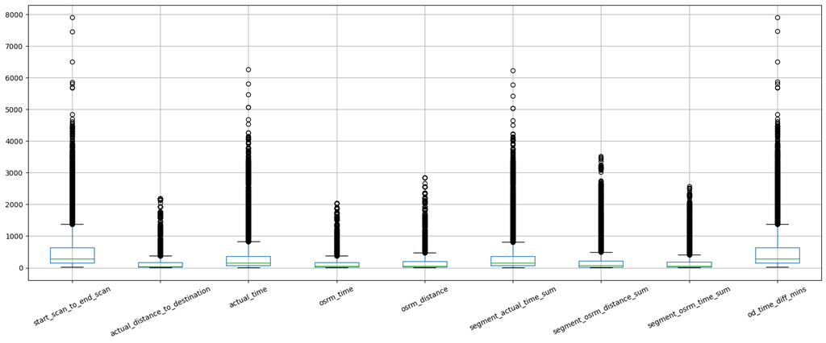

```python
trip[numeric_cols].boxplot(rot=25, figsize=(20,7))
```

- All the numeric attributes are having outliers

## Handling the Outliers - Using IQR

```python
Q1 = trip[numeric_cols].quantile(0.25)
Q3 = trip[numeric_cols].quantile(0.75)
```

```python
IQR = Q3 - Q1
```

```python
trip = trip[~((trip[numeric_cols] < (Q1 - 1.5 * IQR)) | (trip[numeric_cols] > (Q3 + 1.5 * IQR))).any(axis=1)]
```

```python
trip.head()
```

|  | data | trip_creation_time | route_schedule_uuid | route_type | trip_uuid | source_center | source_name | destination_center | destination_name | start_scan_to_end_scan | ... | destination_state | destination_city | destination_place | destination_code | trip_year | trip_month | trip_hour | trip_day | trip_week | trip_dayofweek |
| --- | --- | --- | --- | --- | --- | --- | --- | --- | --- | --- | --- | --- | --- | --- | --- | --- | --- | --- | --- | --- | --- |
| 1 | training | 2018-09-12 00:00:22.886430 | thanos::sroute:3a1b0ab2-bb0b-4c53-8c59-eb2a2c0... | Carting | trip-153671042288605164 | IND561203AAB | doddablpur_chikadpp_d (karnataka) | IND561203AAB | doddablpur_chikadpp_d (karnataka) | 180.0 | ... | karnataka | doddablpur | chikadpp | d | 2018 | 9 | 0 | 12 | 37 | 2 |
| 3 | training | 2018-09-12 00:01:00.113710 | thanos::sroute:f0176492-a679-4597-8332-bbd1c7f... | Carting | trip-153671046011330457 | IND400072AAB | mumbai hub (maharashtra) | IND401104AAA | mumbai_mirard_ip (maharashtra) | 100.0 | ... | maharashtra | mumbai | mirard | ip | 2018 | 9 | 0 | 12 | 37 | 2 |
| 4 | training | 2018-09-12 00:02:09.740725 | thanos::sroute:d9f07b12-65e0-4f3b-bec8-df06134... | FTL | trip-153671052974046625 | IND583101AAA | bellary_dc (karnataka) | IND583119AAA | sandur_wrdn1dpp_d (karnataka) | 717.0 | ... | karnataka | sandur | wrdn1dpp | d | 2018 | 9 | 0 | 12 | 37 | 2 |
| 5 | training | 2018-09-12 00:02:34.161600 | thanos::sroute:9bf03170-d0a2-4a3f-aa4d-9aaab3d... | Carting | trip-153671055416136166 | IND600056AAA | chennai_poonamallee (tamil nadu) | IND600056AAA | chennai_poonamallee (tamil nadu) | 189.0 | ... | tamil nadu | chennai | chennai | none | 2018 | 9 | 0 | 12 | 37 | 2 |
| 6 | training | 2018-09-12 00:04:22.011653 | thanos::sroute:a97698cc-846e-41a7-916b-88b1741... | Carting | trip-153671066201138152 | IND600044AAD | chennai_chrompet_dpc (tamil nadu) | IND600048AAA | chennai_vandalur_dc (tamil nadu) | 98.0 | ... | tamil nadu | chennai | vandalur | dc | 2018 | 9 | 0 | 12 | 37 | 2 |

5 rows × 32 columns

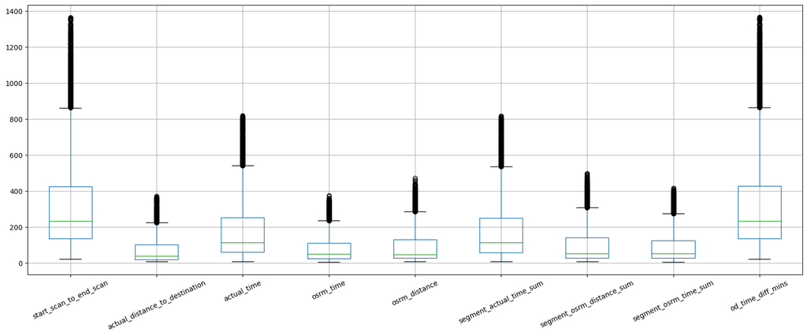

```python
trip[numeric_cols].boxplot(rot=25, figsize=(20,7))
```

[output not shown]

[output cut: 44 more lines]

[output not shown]

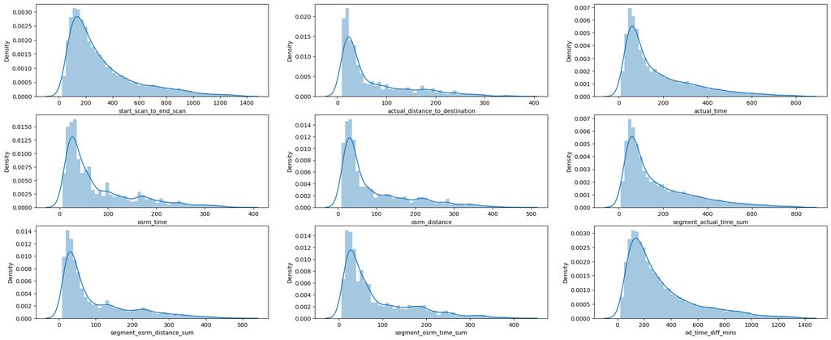

```python
i=1
plt.figure(figsize=(25,10))
for col in numeric_cols:
  plt.subplot(3,3,i)
  sns.distplot(trip[col])
  i+=1
```

- All the numeric columns are right skewed as these attributes can't take negative values

# Comparing the time and Distance fields

## Visual Representation of start_scan_to_end_scan Vs od_time_diff_mins

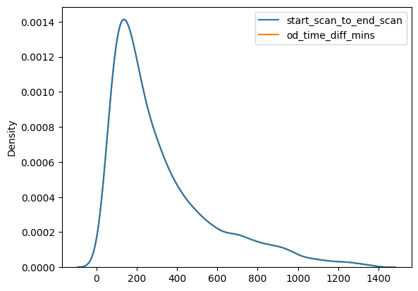

```python
sns.kdeplot([trip['start_scan_to_end_scan'], trip['od_time_diff_mins']])
```

## Describing start_scan_to_end_scan Vs od_time_diff_mins

```python
trip[['start_scan_to_end_scan','od_time_diff_mins']].describe()
```

|  | start_scan_to_end_scan | od_time_diff_mins |
| --- | --- | --- |
| count | 12744.000000 | 12744.000000 |
| mean | 322.166824 | 323.014710 |
| std | 257.550322 | 257.882213 |
| min | 23.000000 | 23.461468 |
| 25% | 136.000000 | 136.810326 |
| 50% | 234.000000 | 234.379203 |
| 75% | 427.000000 | 428.355026 |
| max | 1366.000000 | 1367.376591 |

- Graphically and non-graphically we see very minor difference between start_scan_to_end_scan and od_time_diff_mins
- Now we need to check if the difference is statistically significant or not

## Hypothesis testing for start_scan_to_end_scan and od_time_diff_mins : to validate if both have the same mean or not

- Ho : start_scan_to_end_scan and od_time_diff_mins have equal mean
- Ha : start_scan_to_end_scan and od_time_diff_mins have different mean
- Confidence Level : 95%
- alpha : 0.05

```python
sstes = trip['start_scan_to_end_scan'].sample(5000)
otdm = trip['od_time_diff_mins'].sample(5000)
```

```python
from scipy.stats import ttest_ind

test_stat, p_value = ttest_ind(sstes,otdm)
print('Test Statistic : ', test_stat)
print('P-Value : ', p_value)
```

```
Test Statistic :  1.8960159359814084
P-Value :  0.05798674287115718
```

- As P-Value is greater than alpha, we fail to reject Ho
  - Ho : start_scan_to_end_scan and od_time_diff_mins have the equal mean
- We can conclude that there is no significant difference between start_scan_to_end_scan and od_time_diff_mins

## Visual Representation of actual_time Vs osrm_time

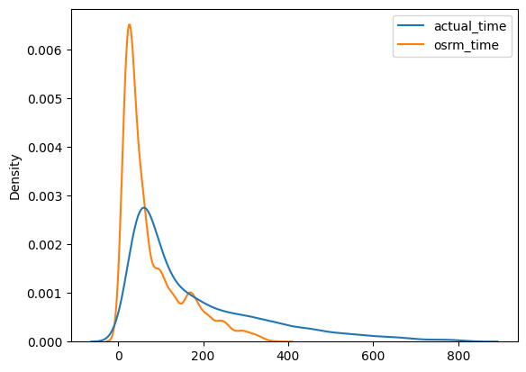

```python
sns.kdeplot([trip['actual_time'], trip['osrm_time']])
```

- Graphically and non-graphically we see actual_time Vs osrm_time follows different distribution
- Now we need to check if the difference is statistically significant or not

## Describing actual_time Vs osrm_time

```python
trip[['actual_time','osrm_time']].describe()
```

|  | actual_time | osrm_time |
| --- | --- | --- |
| count | 12744.000000 | 12744.000000 |
| mean | 178.612837 | 78.992546 |
| std | 159.187899 | 72.898179 |
| min | 9.000000 | 6.000000 |
| 25% | 61.000000 | 27.000000 |
| 50% | 115.000000 | 50.000000 |
| 75% | 254.000000 | 111.000000 |
| max | 820.000000 | 376.000000 |

## Hypothesis testing for actual_time and osrm_time : to validate if both have the same mean or not

- Ho : actual_time and osrm_time have equal mean
- Ha : actual_time and osrm_time have different mean
- Confidence Level : 95%
- alpha : 0.05

```python
at = trip['actual_time'].sample(5000)
ot = trip['osrm_time'].sample(5000)
```

```python
from scipy.stats import ttest_ind

test_stat, p_value = ttest_ind(at, ot)
print('Test Statistic : ', test_stat)
print('P-Value : ', p_value)
```

```
Test Statistic :  41.35299976609893
P-Value :  0.0
```

- As P-Value is smaller than alpha, we reject Ho
  - Ha : actual_time and osrm_time have different mean
- We can conclude that there is significant difference between actual_time and osrm_time

## Visual Representation of actual_time Vs segment_actual_time_sum

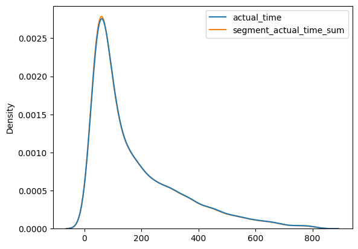

```python
sns.kdeplot([trip['actual_time'], trip['segment_actual_time_sum']])
```

## Describing actual_time Vs segment_actual_time_sum

```python
trip[['actual_time','segment_actual_time_sum']].describe()
```

|  | actual_time | segment_actual_time_sum |
| --- | --- | --- |
| count | 12744.000000 | 12744.000000 |
| mean | 178.612837 | 176.948682 |
| std | 159.187899 | 158.133558 |
| min | 9.000000 | 9.000000 |
| 25% | 61.000000 | 60.000000 |
| 50% | 115.000000 | 114.000000 |
| 75% | 254.000000 | 251.000000 |
| max | 820.000000 | 818.000000 |

- Graphically and non-graphically we see very minor difference between actual_time and segment_actual_time_sum
- Now we need to check if the difference is statistically significant or not

## Hypothesis testing for actual_time and segment_actual_time_sum : to validate if both have the same mean or not

- Ho : actual_time and segment_actual_time_sum have equal mean
- Ha : actual_time and segment_actual_time_sum have different mean
- Confidence Level : 95%
- alpha : 0.05

```python
at = trip['actual_time'].sample(5000)
sats = trip['segment_actual_time_sum'].sample(5000)
```

```python
from scipy.stats import ttest_ind

test_stat, p_value = ttest_ind(at, sats)
print('Test Statistic : ', test_stat)
print('P-Value : ', p_value)
```

```
Test Statistic :  1.0192472679893512
P-Value :  0.308110253927865
```

- As P-Value is greater than alpha, we fail to reject Ho
  - Ho : actual_time and segment_actual_time_sum have equal mean
- We can conclude that there is no significant difference between actual_time and segment_actual_time_sum

## Visual Representation of osrm_distance Vs segment_osrm_distance_sum

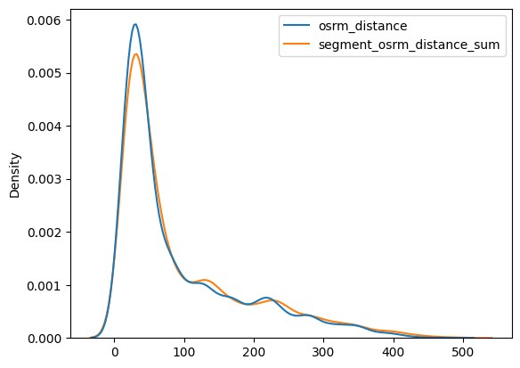

```python
sns.kdeplot([trip['osrm_distance'], trip['segment_osrm_distance_sum']])
```

## Describing osrm_distance and segment_osrm_distance_sum

```python
trip[['osrm_distance','segment_osrm_distance_sum']].describe()
```

|  | osrm_distance | segment_osrm_distance_sum |
| --- | --- | --- |
| count | 12744.000000 | 12744.000000 |
| mean | 92.396940 | 98.697578 |
| std | 90.244340 | 95.577469 |
| min | 9.072900 | 9.072900 |
| 25% | 28.357800 | 29.464775 |
| 50% | 48.619050 | 54.226200 |
| 75% | 132.065825 | 141.580900 |
| max | 474.133700 | 497.792900 |

## Hypothesis testing for osrm_distance and segment_osrm_distance_sum : to validate if both have the same mean or not

- Ho : osrm_distance and segment_osrm_distance_sum have equal mean
- Ha : osrm_distance and segment_osrm_distance_sum have different mean
- Confidence Level : 95%
- alpha : 0.05

```python
od = trip['osrm_distance'].sample(5000)
sods = trip['segment_osrm_distance_sum'].sample(5000)
```

```python
from scipy.stats import ttest_ind

test_stat, p_value = ttest_ind(od,sods)
print('Test Statistic : ', test_stat)
print('P-Value : ', p_value)
```

```
Test Statistic :  -2.4629403047896328
P-Value :  0.013797014498887886
```

## Visual Representation of osrm_time and segment_osrm_time_sum

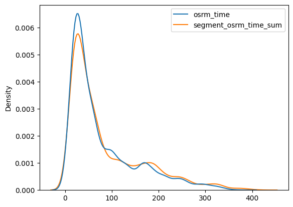

```python
sns.kdeplot([trip['osrm_time'], trip['segment_osrm_time_sum']])
```

## Describing osrm_time and segment_osrm_time_sum

```python
trip[['osrm_time','segment_osrm_time_sum']].describe()
```

|  | osrm_time | segment_osrm_time_sum |
| --- | --- | --- |
| count | 12744.000000 | 12744.000000 |
| mean | 78.992546 | 86.527150 |
| std | 72.898179 | 80.244315 |
| min | 6.000000 | 6.000000 |
| 25% | 27.000000 | 28.000000 |
| 50% | 50.000000 | 53.000000 |
| 75% | 111.000000 | 127.000000 |
| max | 376.000000 | 417.000000 |

## Hypothesis testing for osrm_time and segment_osrm_time_sum : to validate if both have the same mean or not

- Ho : osrm_time and segment_osrm_time_sum have equal mean
- Ha : osrm_time and segment_osrm_time_sum have different mean
- Confidence Level : 95%
- alpha : 0.05

```python
ot = trip['osrm_time'].sample(5000)
sots = trip['segment_osrm_time_sum'].sample(5000)
```

```python
from scipy.stats import ttest_ind

test_stat, p_value = ttest_ind(ot,sots)
print('Test Statistic : ', test_stat)
print('P-Value : ', p_value)
```

```
Test Statistic :  -5.4671267539897554
P-Value :  4.683901655635288e-08
```

## Handling Categorical Variables

```python
trip['route_type'].value_counts()
```

| route_type | count |
| --- | --- |
| Carting | 8816 |
| FTL | 3928 |

**dtype:** int64

```python
# One Hot Encoding
trip['route_type'] = trip['route_type'].map({'FTL':0, 'Carting':1})
```

```python
trip['route_type'].value_counts()
```

| route_type | count |
| --- | --- |
| 1 | 8816 |
| 0 | 3928 |

**dtype:** int64

# Standardizing the Numercal Columns

```python
from sklearn.preprocessing import StandardScaler
```

```python
scaler = StandardScaler()
scaler.fit(trip[numeric_cols])
trip[numeric_cols] = scaler.transform(trip[numeric_cols])
```

```python
trip[numeric_cols]
```

|  | start_scan_to_end_scan | actual_distance_to_destination | actual_time | osrm_time | osrm_distance | segment_actual_time_sum | segment_osrm_distance_sum | segment_osrm_time_sum | od_time_diff_mins |
| --- | --- | --- | --- | --- | --- | --- | --- | --- | --- |
| 1 | -0.552018 | 0.004770 | -0.223725 | -0.150799 | -0.080739 | -0.227340 | -0.151801 | -0.268281 | -0.548345 |
| 3 | -0.862649 | -0.766652 | -0.751424 | -0.877869 | -0.805810 | -0.745909 | -0.824714 | -0.878940 | -0.862908 |
| 4 | 1.533093 | 0.752089 | 1.020137 | 0.521398 | 0.602775 | 1.031139 | 0.503217 | 0.354841 | 1.533064 |
| 5 | -0.517072 | -0.664436 | -0.738859 | -0.768123 | -0.712895 | -0.739585 | -0.739041 | -0.791703 | -0.513925 |
| 6 | -0.870415 | -0.877862 | -0.971298 | -0.905306 | -0.890712 | -0.967250 | -0.906935 | -0.916327 | -0.872561 |
| ... | ... | ... | ... | ... | ... | ... | ... | ... | ... |
| 14812 | -0.253036 | -0.207666 | -0.600652 | -0.233109 | -0.209816 | -0.600457 | -0.354098 | -0.305668 | -0.252008 |
| 14813 | -1.017965 | -0.789535 | -0.990144 | -0.919024 | -0.845612 | -0.986222 | -0.864351 | -0.941252 | -1.017653 |
| 14814 | 0.383758 | -0.470411 | 0.649492 | -0.425165 | -0.371154 | 0.658022 | 0.064757 | 0.018355 | 0.384319 |
| 14815 | 0.096424 | 0.852289 | 0.536413 | 1.371932 | 0.872259 | 0.512570 | 1.306163 | 1.675859 | 0.098879 |
| 14816 | 0.119722 | -0.093089 | 0.605517 | -0.150799 | -0.130963 | 0.613754 | -0.189580 | -0.243356 | 0.121738 |

12744 rows × 9 columns

```python
trip[numeric_cols].describe()
```

|  | start_scan_to_end_scan | actual_distance_to_destination | actual_time | osrm_time | osrm_distance | segment_actual_time_sum | segment_osrm_distance_sum | segment_osrm_time_sum | od_time_diff_mins |
| --- | --- | --- | --- | --- | --- | --- | --- | --- | --- |
| count | 1.274400e+04 | 1.274400e+04 | 1.274400e+04 | 1.274400e+04 | 1.274400e+04 | 1.274400e+04 | 1.274400e+04 | 1.274400e+04 | 1.274400e+04 |
| mean | 3.289550e-17 | 1.003591e-17 | -7.805711e-18 | -9.478364e-17 | 6.690610e-17 | -2.787754e-17 | -5.017957e-17 | -3.345305e-17 | 2.425346e-17 |
| std | 1.000039e+00 | 1.000039e+00 | 1.000039e+00 | 1.000039e+00 | 1.000039e+00 | 1.000039e+00 | 1.000039e+00 | 1.000039e+00 | 1.000039e+00 |
| min | -1.161631e+00 | -8.792127e-01 | -1.065530e+00 | -1.001334e+00 | -9.233522e-01 | -1.062110e+00 | -9.377544e-01 | -1.003564e+00 | -1.161635e+00 |
| 25% | -7.228651e-01 | -7.084152e-01 | -7.388593e-01 | -7.132494e-01 | -7.096473e-01 | -7.395854e-01 | -7.243916e-01 | -7.293906e-01 | -7.220804e-01 |
| 50% | -3.423420e-01 | -4.707926e-01 | -3.996242e-01 | -3.977285e-01 | -4.851230e-01 | -3.980885e-01 | -4.653097e-01 | -4.178298e-01 | -3.437189e-01 |
| 75% | 4.070556e-01 | 4.176759e-01 | 4.735920e-01 | 4.390879e-01 | 4.395893e-01 | 4.683018e-01 | 4.486937e-01 | 5.043901e-01 | 4.084983e-01 |
| max | 4.053088e+00 | 4.140033e+00 | 4.029278e+00 | 4.074438e+00 | 4.230201e+00 | 4.054019e+00 | 4.175785e+00 | 4.118495e+00 | 4.049922e+00 |

## Insights

```python
trip['source_state'].value_counts().sort_values(ascending=False).head(3)
```

| source_state | count |
| --- | --- |
| maharashtra | 2309 |
| karnataka | 2025 |
| haryana | 1376 |

**dtype:** int64

```python
trip['source_state'].value_counts().sort_values(ascending=True).head(3)
```

| source_state | count |
| --- | --- |
| arunachal pradesh | 3 |
| nagaland | 4 |
| himachal pradesh | 12 |

**dtype:** int64

```python
trip[trip['source_state']=='maharashtra']['source_city'].value_counts().head(5)
```

| source_city | count |
| --- | --- |
| mumbai | 666 |
| bhiwandi | 541 |
| pune | 357 |
| mumbai hub | 300 |
| lowerparel | 65 |

**dtype:** int64

```python
trip['source_city'].value_counts().sort_values(ascending=False).head(3)
```

| source_city | count |
| --- | --- |
| bengaluru | 1113 |
| gurgaon | 753 |
| mumbai | 666 |

**dtype:** int64

```python
trip['source_city'].value_counts().sort_values(ascending=True).head(3)
```

| source_city | count |
| --- | --- |
| jetpur | 1 |
| kadiri | 1 |
| vadakkencherry | 1 |

**dtype:** int64

```python
trip.groupby(['source_state','destination_state'])['trip_uuid'].count().sort_values(ascending=False)
```

| source_state | destination_state | trip_uuid |
| --- | --- | --- |
| maharashtra | maharashtra | 2276 |
| karnataka | karnataka | 2007 |
| tamil nadu | tamil nadu | 1016 |
| haryana | haryana | 795 |
| telangana | telangana | 669 |
| ... | ... | ... |
| karnataka | goa | 1 |
| tamil nadu | andhra pradesh | 1 |
|  | kerala | 1 |
| uttar pradesh | uttarakhand | 1 |
| west bengal | orissa | 1 |

90 rows × 1 columns

**dtype:** int64

```python
trip.groupby(['source_center','destination_center'])['trip_uuid'].count().sort_values(ascending=False)
```

| source_center | destination_center | trip_uuid |
| --- | --- | --- |
| IND562132AAA | IND560300AAA | 151 |
| IND560099AAB | IND560300AAA | 121 |
| IND560300AAA | IND562132AAA | 108 |
| IND421302AAG | IND400072AAB | 105 |
| IND400072AAD | IND421302AAG | 99 |
| ... | ... | ... |
| IND848114AAA | IND842001AAA | 1 |
| IND000000AAZ | IND444005AAB | 1 |
|  | IND444203AAA | 1 |
| IND854326AAB | IND854105AAB | 1 |
| IND000000ACB | IND123106AAB | 1 |

1991 rows × 1 columns

**dtype:** int64

```python
np.mean(trip[(trip['source_center']=='IND562132AAA') & (trip['destination_center']=='IND560300AAA')]['actual_distance_to_destination'])
```

```
np.float64(-0.6172637504584045)
```

```python
np.mean(trip[(trip['source_center']=='IND562132AAA') & (trip['destination_center']=='IND560300AAA')]['actual_time'])
```

```
np.float64(-0.5700321837180513)
```

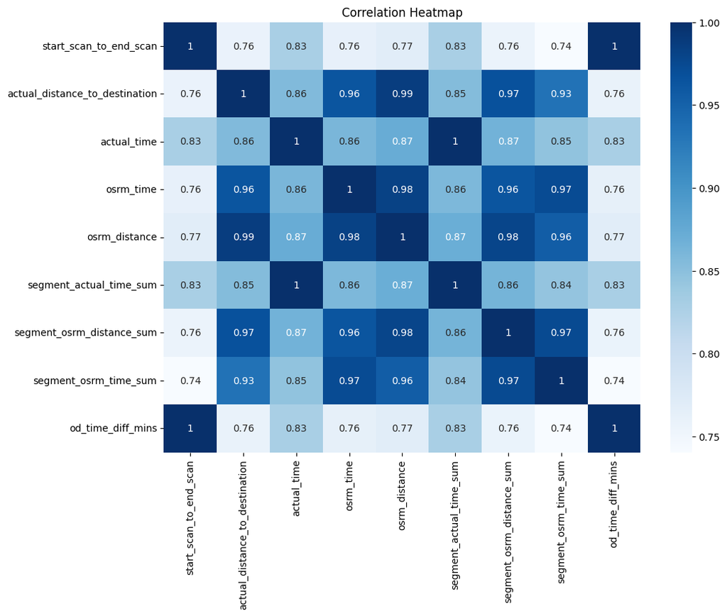

```python
plt.figure(figsize=(11,8))
plt.title('Correlation Heatmap')
sns.heatmap(trip[numeric_cols].corr(method = 'pearson'),annot=True,cmap='Blues')
```

```python
trip[trip['source_state']==trip['destination_state']]['trip_uuid'].count()/len(trip)
```

```
np.float64(0.8666038920276209)
```

```python
trip['trip_dayofweek'].value_counts()
```

| trip_dayofweek | count |
| --- | --- |
| 2 | 2357 |
| 5 | 1839 |
| 3 | 1823 |
| 4 | 1777 |
| 1 | 1769 |
| 0 | 1697 |
| 6 | 1482 |

**dtype:** int64

# Business Insights

- Max orders are coming from state Maharashtra and the top 3 contributor cities are Mumbai, Bhiwandi, Pune
- Least orders were booked in Arunachal Pradesh, Nagaland, Himachal Pradesh
- At city level max orders are coming from Bengaluru, Gurgaon, Mumbai
- At city level min orders were placed Jetpur, Kadiri, Vadakkencherry
- Some cities appear under multiple names. Eg: Mumbai has been referred to as Mumbai, Mumbai hub, Lower Parel etc. If these different city names identify the same city, it could alter which city ranks highest in deliveries.
- Most of the orders are within the state (86.67%)
- Busiest route is IND562132AAA (bangalore_nelmngla_h (karnataka)) to IND560300AAA (bengaluru_kgairprt_hb (karnataka))
  - Average distance : 28.022 Km
  - Average time taken : 87.87 mins
- Max orders were booked on Wednesday followed by Saturday
- There is a significant difference between OSRM and actual parameters

## Recommendation

### There is a need to:

- Revisit information fed to routing engine for trip planning.Check for discrepancies with transporters, if the routing engine is configured for optimum results.
- North, South and West Zones corridors have significant traffic of orders. But, we have a smaller presence in Central, Eastern and North-Eastern zone. However it would be difficult to conclude this, by looking at just 2 months data. It is worth investigating and increasing our presence in these regions.
- More campaign / advertisement in the states with less orders like Arunachal, Nagaland, Himachal etc.
- From state point of view, we have heavy traffic in Mahrashtra followed by Karnataka. This is a good indicator that we need to plan for resources on ground in these 2 states on priority. Especially, during festive seasons.
- Some cities appear under multiple names. Eg: Mumbai has been referred to as Mumbai, Mumbai hub, Lower Parel etc. If these different city names identify the same city, it could alter which city ranks highest in deliveries. Hence, it is recommended to clarify whether these names should be consolidated under one city or treated as separate locations